# Tutorium-18-06-CaseStudy-Seattle house prices

dzt

6/18/2021

This dataset contains house sale prices for King County, which includes Seattle. It includes homes sold between May 2014 and May 2015.

It’s a great dataset for evaluating simple regression models.

Dataset is from : https://www.kaggle.com/harlfoxem/housesalesprediction

Case Study is here : https://moderndive.com/11-thinking-with-data.html#seattle-house-prices

In this case study, we’ll create a multiple regression model where:

The outcome variable y is the sale price of houses.

# EDA

```r
library(tidyverse)
library(moderndive)
library(skimr)
library(fivethirtyeight)
```

## Overview

```r
skim(house_prices)
```

Data summary

| Name | house_prices |
| --- | --- |
| Number of rows | 21613 |
| Number of columns | 21 |
| _______________________ |  |
| Column type frequency: |  |
| character | 1 |
| Date | 1 |
| factor | 3 |
| logical | 1 |
| numeric | 15 |
| ________________________ |  |
| Group variables | None |

**Variable type: character**

| skim_variable | n_missing | complete_rate | min | max | empty | n_unique | whitespace |
| --- | --- | --- | --- | --- | --- | --- | --- |
| id | 0 | 1 | 10 | 10 | 0 | 21436 | 0 |

**Variable type: Date**

| skim_variable | n_missing | complete_rate | min | max | median | n_unique |
| --- | --- | --- | --- | --- | --- | --- |
| date | 0 | 1 | 2014-05-02 | 2015-05-27 | 2014-10-16 | 372 |

**Variable type: factor**

| skim_variable | n_missing | complete_rate | ordered | n_unique | top_counts |
| --- | --- | --- | --- | --- | --- |
| condition | 0 | 1 | FALSE | 5 | 3: 14031, 4: 5679, 5: 1701, 2: 172 |
| grade | 0 | 1 | FALSE | 12 | 7: 8981, 8: 6068, 9: 2615, 6: 2038 |
| zipcode | 0 | 1 | FALSE | 70 | 981: 602, 980: 590, 981: 583, 980: 574 |

**Variable type: logical**

| skim_variable | n_missing | complete_rate | mean | count |
| --- | --- | --- | --- | --- |
| waterfront | 0 | 1 | 0.01 | FAL: 21450, TRU: 163 |

**Variable type: numeric**

| skim_variable | n_missing | complete_rate | mean | sd | p0 | p25 | p50 | p75 | p100 | hist |
| --- | --- | --- | --- | --- | --- | --- | --- | --- | --- | --- |
| price | 0 | 1 | 540088.14 | 367127.20 | 75000.00 | 321950.00 | 450000.00 | 645000.00 | 7700000.00 | ▇▁▁▁▁ |
| bedrooms | 0 | 1 | 3.37 | 0.93 | 0.00 | 3.00 | 3.00 | 4.00 | 33.00 | ▇▁▁▁▁ |
| bathrooms | 0 | 1 | 2.11 | 0.77 | 0.00 | 1.75 | 2.25 | 2.50 | 8.00 | ▃▇▁▁▁ |
| sqft_living | 0 | 1 | 2079.90 | 918.44 | 290.00 | 1427.00 | 1910.00 | 2550.00 | 13540.00 | ▇▂▁▁▁ |
| sqft_lot | 0 | 1 | 15106.97 | 41420.51 | 520.00 | 5040.00 | 7618.00 | 10688.00 | 1651359.00 | ▇▁▁▁▁ |
| floors | 0 | 1 | 1.49 | 0.54 | 1.00 | 1.00 | 1.50 | 2.00 | 3.50 | ▇▅▁▁▁ |
| view | 0 | 1 | 0.23 | 0.77 | 0.00 | 0.00 | 0.00 | 0.00 | 4.00 | ▇▁▁▁▁ |
| sqft_above | 0 | 1 | 1788.39 | 828.09 | 290.00 | 1190.00 | 1560.00 | 2210.00 | 9410.00 | ▇▃▁▁▁ |
| sqft_basement | 0 | 1 | 291.51 | 442.58 | 0.00 | 0.00 | 0.00 | 560.00 | 4820.00 | ▇▁▁▁▁ |
| yr_built | 0 | 1 | 1971.01 | 29.37 | 1900.00 | 1951.00 | 1975.00 | 1997.00 | 2015.00 | ▂▃▇▇▇ |
| yr_renovated | 0 | 1 | 84.40 | 401.68 | 0.00 | 0.00 | 0.00 | 0.00 | 2015.00 | ▇▁▁▁▁ |
| lat | 0 | 1 | 47.56 | 0.14 | 47.16 | 47.47 | 47.57 | 47.68 | 47.78 | ▁▃▅▇▇ |
| long | 0 | 1 | -122.21 | 0.14 | -122.52 | -122.33 | -122.23 | -122.12 | -121.32 | ▇▇▂▁▁ |
| sqft_living15 | 0 | 1 | 1986.55 | 685.39 | 399.00 | 1490.00 | 1840.00 | 2360.00 | 6210.00 | ▅▇▂▁▁ |
| sqft_lot15 | 0 | 1 | 12768.46 | 27304.18 | 651.00 | 5100.00 | 7620.00 | 10083.00 | 871200.00 | ▇▁▁▁▁ |

## Reshaping the data (pivot_longer)

```r
house_prices_pivot <-
select_if(house_prices,is.numeric) %>%  # select only numbers
  pivot_longer(everything(), names_to = "variable")
  # everything() is a convenient shorthand to pivot all variables. pivot_longer(everything()) https://jhudatascience.org/tidyversecourse/wrangle-data.html
house_prices_pivot
```

```
## # A tibble: 324,195 x 2
##    variable       value
##    <chr>          <dbl>
##  1 price         221900
##  2 bedrooms           3
##  3 bathrooms          1
##  4 sqft_living     1180
##  5 sqft_lot        5650
##  6 floors             1
##  7 view               0
##  8 sqft_above      1180
##  9 sqft_basement      0
## 10 yr_built        1955
## # … with 324,185 more rows
```

## Distribution of all predictors

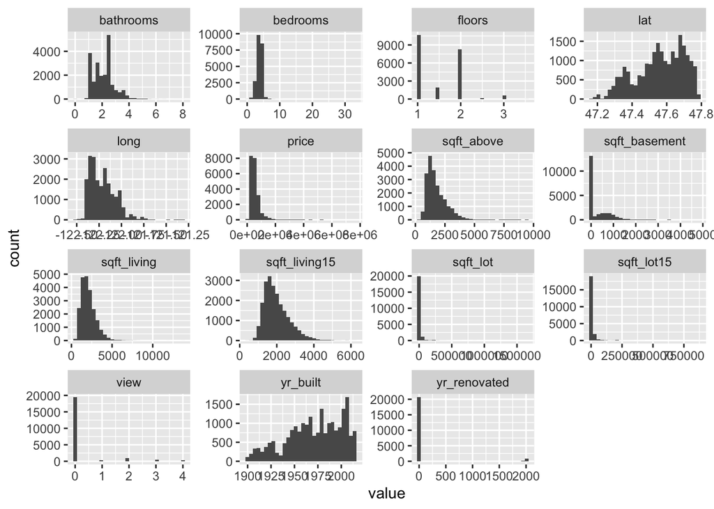

```r
  ggplot(house_prices_pivot,aes(x = value)) +
  geom_histogram() +
  facet_wrap(~ variable, scales = "free")
```

For both the price and sqft_living variables, the right-skew makes distinguishing houses at the lower end of the x-axis hard. This is because the scale of the x-axis is compressed by the small number of quite expensive and immensely-sized houses.

## log10 transformation to right-skew variables

```r
house_prices <- house_prices %>%
  mutate(
    log10_price = log10(price),
    log10_size = log10(sqft_living)
    )
```

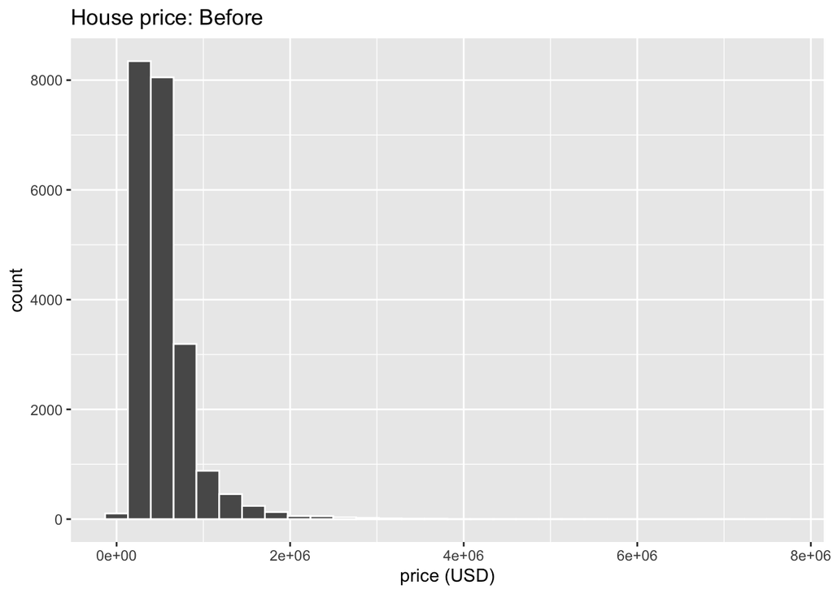

```r
# Before log10 transformation:
ggplot(house_prices, aes(x = price)) +
  geom_histogram(color = "white") +
  labs(x = "price (USD)", title = "House price: Before")
```

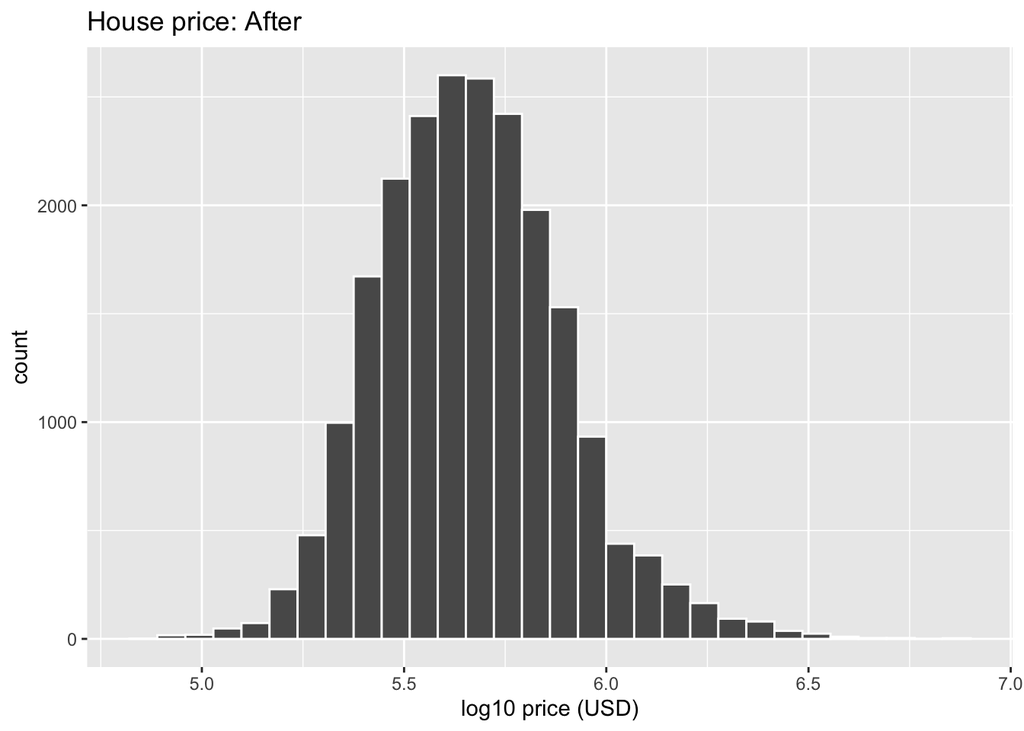

```r
# After log10 transformation:
ggplot(house_prices, aes(x = log10_price)) +
  geom_histogram(color = "white") +
  labs(x = "log10 price (USD)", title = "House price: After")
```

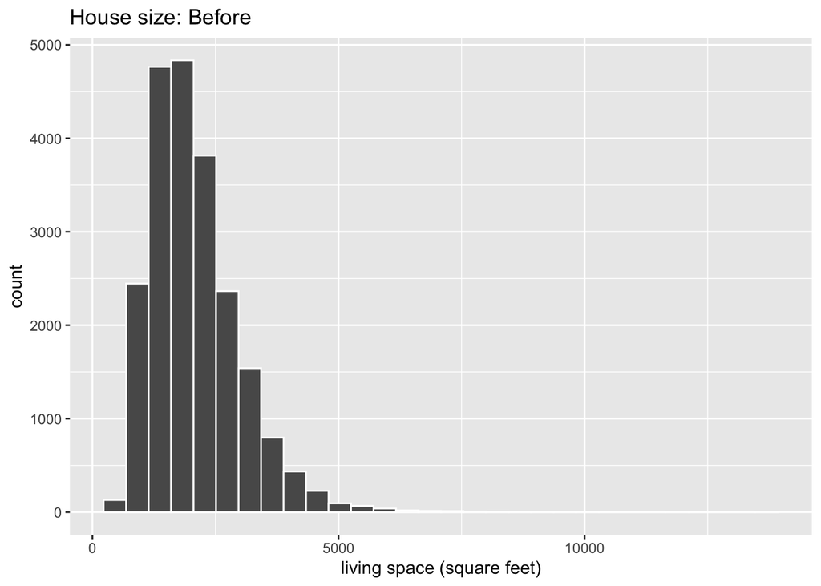

```r
# Before log10 transformation:
ggplot(house_prices, aes(x = sqft_living)) +
  geom_histogram(color = "white") +
  labs(x = "living space (square feet)", title = "House size: Before")
```

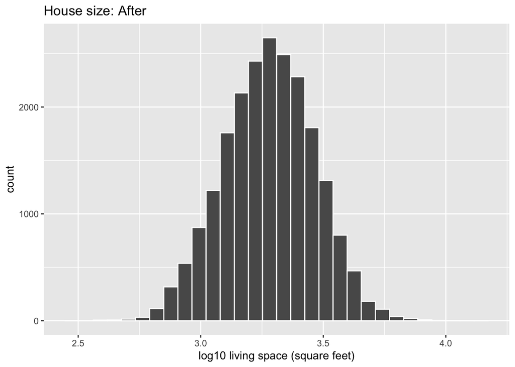

```r
# After log10 transformation:
ggplot(house_prices, aes(x = log10_size)) +
  geom_histogram(color = "white") +
  labs(x = "log10 living space (square feet)", title = "House size: After")
```

## Dataset division in Train and Test

```r
train <-  slice_sample(house_prices, prop=.75)
train
```

```
## # A tibble: 16,209 x 23
##    id         date         price bedrooms bathrooms sqft_living sqft_lot floors
##    <chr>      <date>       <dbl>    <int>     <dbl>       <int>    <int>  <dbl>
##  1 0751000020 2014-06-26  290000        2      1            930     7740    1
##  2 6084200100 2014-08-01  400000        3      2.5         2120     3742    2
##  3 2619950070 2014-08-26  430000        4      2.5         2750     7200    2
##  4 3751606606 2014-07-17  262500        3      1.75        2259    26831    1.5
##  5 3298700125 2014-09-05  280000        2      1            910     4662    1
##  6 6021501780 2014-08-18  578000        3      1           1500     4500    1
##  7 8085400055 2015-04-28 1582500        4      2.5         3980    16304    1
##  8 3459600180 2014-06-26  827000        4      2.5         3230    12100    1
##  9 1088400190 2015-04-22  305000        3      1           1120    10125    1
## 10 7977201065 2015-03-05  740000        3      1.75        1380     4590    1
## # … with 16,199 more rows, and 15 more variables: waterfront <lgl>, view <int>,
## #   condition <fct>, grade <fct>, sqft_above <int>, sqft_basement <int>,
## #   yr_built <int>, yr_renovated <int>, zipcode <fct>, lat <dbl>, long <dbl>,
## #   sqft_living15 <int>, sqft_lot15 <int>, log10_price <dbl>, log10_size <dbl>
```

```r
test <- anti_join(house_prices, train, by="id")
test
```

```
## # A tibble: 5,346 x 23
##    id         date         price bedrooms bathrooms sqft_living sqft_lot floors
##    <chr>      <date>       <dbl>    <int>     <dbl>       <int>    <int>  <dbl>
##  1 2487200875 2014-12-09  604000        4      3           1960     5000    1
##  2 7237550310 2014-05-12 1225000        4      4.5         5420   101930    1
##  3 1321400060 2014-06-27  257500        3      2.25        1715     6819    2
##  4 6300500875 2014-05-14  385000        4      1.75        1620     4980    1
##  5 2524049179 2014-08-26 2000000        3      2.75        3050    44867    1
##  6 7137970340 2014-07-03  285000        5      2.5         2270     6300    2
##  7 1794500383 2014-06-26  937000        3      1.75        2450     2691    2
##  8 1873100390 2015-03-02  719000        4      2.5         2570     7173    2
##  9 2426039314 2014-12-01  280000        2      1.5         1190     1265    3
## 10 9547205180 2014-06-13  696000        3      2.5         2300     3060    1.5
## # … with 5,336 more rows, and 15 more variables: waterfront <lgl>, view <int>,
## #   condition <fct>, grade <fct>, sqft_above <int>, sqft_basement <int>,
## #   yr_built <int>, yr_renovated <int>, zipcode <fct>, lat <dbl>, long <dbl>,
## #   sqft_living15 <int>, sqft_lot15 <int>, log10_price <dbl>, log10_size <dbl>
```

## Check outliers in outcome using Z value

z=(x-mean)/sd

```r
train_outliers<-
train %>%
mutate(price_z = (price - mean(price, na.rm = TRUE)) /
sd(price, na.rm = TRUE)) %>%
mutate(is_extreme = if_else(abs(price_z) > 3, TRUE, FALSE)) %>%
count(is_extreme)
```

```r
train_outliers
```

```
## # A tibble: 2 x 2
##   is_extreme     n
##   <lgl>      <int>
## 1 FALSE      15930
## 2 TRUE         279
```

TRUE: outliers FALSE : not outliers

## Drop outliers in outcome (filter)

```r
train_outliers <- train%>%mutate(price_z = (price - mean(price, na.rm = TRUE)) /
sd(price, na.rm = TRUE)) %>%
mutate(is_extreme = if_else(abs(price_z) > 3, TRUE, FALSE))
train_outliers
```

```
## # A tibble: 16,209 x 25
##    id         date         price bedrooms bathrooms sqft_living sqft_lot floors
##    <chr>      <date>       <dbl>    <int>     <dbl>       <int>    <int>  <dbl>
##  1 0751000020 2014-06-26  290000        2      1            930     7740    1
##  2 6084200100 2014-08-01  400000        3      2.5         2120     3742    2
##  3 2619950070 2014-08-26  430000        4      2.5         2750     7200    2
##  4 3751606606 2014-07-17  262500        3      1.75        2259    26831    1.5
##  5 3298700125 2014-09-05  280000        2      1            910     4662    1
##  6 6021501780 2014-08-18  578000        3      1           1500     4500    1
##  7 8085400055 2015-04-28 1582500        4      2.5         3980    16304    1
##  8 3459600180 2014-06-26  827000        4      2.5         3230    12100    1
##  9 1088400190 2015-04-22  305000        3      1           1120    10125    1
## 10 7977201065 2015-03-05  740000        3      1.75        1380     4590    1
## # … with 16,199 more rows, and 17 more variables: waterfront <lgl>, view <int>,
## #   condition <fct>, grade <fct>, sqft_above <int>, sqft_basement <int>,
## #   yr_built <int>, yr_renovated <int>, zipcode <fct>, lat <dbl>, long <dbl>,
## #   sqft_living15 <int>, sqft_lot15 <int>, log10_price <dbl>, log10_size <dbl>,
## #   price_z <dbl>, is_extreme <lgl>
```

```r
train <-
  train_outliers %>%
  filter(is_extreme==FALSE)
train
```

```
## # A tibble: 15,930 x 25
##    id         date         price bedrooms bathrooms sqft_living sqft_lot floors
##    <chr>      <date>       <dbl>    <int>     <dbl>       <int>    <int>  <dbl>
##  1 0751000020 2014-06-26  290000        2      1            930     7740    1
##  2 6084200100 2014-08-01  400000        3      2.5         2120     3742    2
##  3 2619950070 2014-08-26  430000        4      2.5         2750     7200    2
##  4 3751606606 2014-07-17  262500        3      1.75        2259    26831    1.5
##  5 3298700125 2014-09-05  280000        2      1            910     4662    1
##  6 6021501780 2014-08-18  578000        3      1           1500     4500    1
##  7 8085400055 2015-04-28 1582500        4      2.5         3980    16304    1
##  8 3459600180 2014-06-26  827000        4      2.5         3230    12100    1
##  9 1088400190 2015-04-22  305000        3      1           1120    10125    1
## 10 7977201065 2015-03-05  740000        3      1.75        1380     4590    1
## # … with 15,920 more rows, and 17 more variables: waterfront <lgl>, view <int>,
## #   condition <fct>, grade <fct>, sqft_above <int>, sqft_basement <int>,
## #   yr_built <int>, yr_renovated <int>, zipcode <fct>, lat <dbl>, long <dbl>,
## #   sqft_living15 <int>, sqft_lot15 <int>, log10_price <dbl>, log10_size <dbl>,
## #   price_z <dbl>, is_extreme <lgl>
```

# Model 1 with transformed predictors (y= log10_price, x1=log10_size, x2=condition)

## Interaction

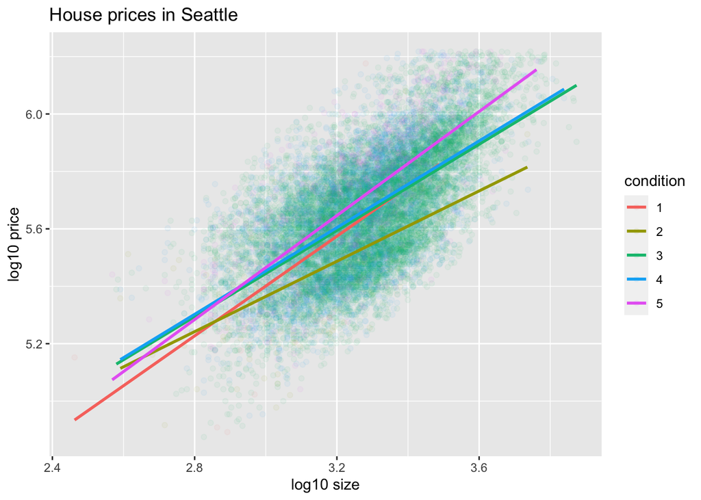

```r
# Plot interaction model
ggplot(train,
       aes(x = log10_size, y = log10_price, col = condition)) +
  geom_point(alpha = 0.05) +
  geom_smooth(method = "lm", se = FALSE) +
  labs(y = "log10 price",
       x = "log10 size",
       title = "House prices in Seattle")
```

we see there is a positive relationship between house price and size, meaning as houses are larger, they tend to be more expensive.

## Fit regression model with log transformation and interaction

```r
# Fit regression model:
price_interaction <- lm(log10_price ~ log10_size * condition,
                        data = train)

# Get regression table:
get_regression_table(price_interaction)
```

```
## # A tibble: 10 x 7
##    term                  estimate std_error statistic p_value lower_ci upper_ci
##    <chr>                    <dbl>     <dbl>     <dbl>   <dbl>    <dbl>    <dbl>
##  1 intercept                2.80      0.516     5.42    0        1.79     3.81
##  2 log10_size               0.868     0.17      5.12    0        0.535    1.2
##  3 condition2               0.73      0.565     1.29    0.196   -0.377    1.84
##  4 condition3               0.396     0.517     0.766   0.444   -0.617    1.41
##  5 condition4               0.391     0.518     0.755   0.45    -0.624    1.41
##  6 condition5              -0.049     0.523    -0.093   0.926   -1.07     0.976
##  7 log10_size:condition2   -0.255     0.185    -1.38    0.168   -0.618    0.107
##  8 log10_size:condition3   -0.117     0.17     -0.692   0.489   -0.45     0.215
##  9 log10_size:condition4   -0.113     0.17     -0.663   0.507   -0.447    0.221
## 10 log10_size:condition5    0.038     0.172     0.22    0.826   -0.299    0.374
```

```r
summary(price_interaction)
```

```
##
## Call:
## lm(formula = log10_price ~ log10_size * condition, data = train)
##
## Residuals:
##      Min       1Q   Median       3Q      Max
## -0.51153 -0.12238  0.01167  0.11160  0.53143
##
## Coefficients:
##                       Estimate Std. Error t value Pr(>|t|)
## (Intercept)            2.79707    0.51574   5.423 5.93e-08 ***
## log10_size             0.86789    0.16959   5.118 3.13e-07 ***
## condition2             0.72963    0.56470   1.292    0.196
## condition3             0.39583    0.51654   0.766    0.444
## condition4             0.39131    0.51796   0.755    0.450
## condition5            -0.04871    0.52282  -0.093    0.926
## log10_size:condition2 -0.25531    0.18503  -1.380    0.168
## log10_size:condition3 -0.11744    0.16981  -0.692    0.489
## log10_size:condition4 -0.11293    0.17023  -0.663    0.507
## log10_size:condition5  0.03770    0.17162   0.220    0.826
## ---
## Signif. codes:  0 '***' 0.001 '**' 0.01 '*' 0.05 '.' 0.1 ' ' 1
##
## Residual standard error: 0.1601 on 15920 degrees of freedom
## Multiple R-squared:  0.4251, Adjusted R-squared:  0.4248
## F-statistic:  1308 on 9 and 15920 DF,  p-value: < 2.2e-16
```

# Prediction

```r
pred <- predict(price_interaction, newdata = test)
```

## reverse transformation in pred

```r
library(modelr)
house_prices <-
  house_prices %>%
  add_predictions(price_interaction,
                  var = "pred_log10") %>%
  mutate(pred = 10^pred_log10)
```

https://data-se.netlify.app/2021/06/18/r%C3%BCcktransformation-logarithmierter-y-werte/

## check

```r
house_prices %>%
  select(price, pred_log10, pred) %>%
  slice(1:10)
```

```
## # A tibble: 10 x 3
##      price pred_log10    pred
##      <dbl>      <dbl>   <dbl>
##  1  221900       5.50 314931.
##  2  538000       5.75 564818.
##  3  180000       5.36 228606.
##  4  604000       5.73 536818.
##  5  510000       5.61 410541.
##  6 1225000       6.00 988793.
##  7  257500       5.62 416943.
##  8  291850       5.46 290578.
##  9  229500       5.63 428747.
## 10  323000       5.65 448481.
```

```r
test2 <- mutate(test, pred)
```

```r
handover<- select(test2, pred,id)
handover
```

```
## # A tibble: 5,346 x 2
##     pred id
##    <dbl> <chr>
##  1  5.73 2487200875
##  2  6.00 7237550310
##  3  5.62 1321400060
##  4  5.61 6300500875
##  5  5.81 2524049179
##  6  5.71 7137970340
##  7  5.74 1794500383
##  8  5.75 1873100390
##  9  5.50 2426039314
## 10  5.72 9547205180
## # … with 5,336 more rows
```